# A Multiple Linear Model for Toronto and Mississauga House Prices

Ziqian Qiu ID1004723383

December 3rd, 2020

## I. Data Wrangling

a). I use set.seed(1004723383) to set my seed of your randomization and select a sample of 150 cases. All 150 ids for my chosen sample is shown below

```r
set.seed(1004723383)
data_AQ3383 = original_data_AQ3383[sample(nrow(original_data_AQ3383), 150), ]
id_AQ3383 = data_AQ3383[, 1]
id_AQ3383
```

```
##   [1]  38  55  80  75 108 193 103   4 161 140  82 167  15  98 133  28 109  95
##  [19]  19 147  47  21 144  13 118   3 170 177 172 116 155  26 138 105  94  78
##  [37]  32  68  66 112 182  63 229  44 153  86  65 154  20  33  79 207  99 131
##  [55]  45 145  97  40 122 162  64  14 194 175  83 204  43  27 183  29  42 113
##  [73]  57 117 106  69  17 165  74 156  54 119  60 141  30 135  51  67 160 169
##  [91] 136  58 157  31 164  22 158  41  50  36 115  85 104 152  48 179  89 171
## [109]  93  53  90 174 149 163   7 110  91 227 111 139  34  56 125   9  61  24
## [127]  84   2  92 166   8  76  73  81   5 168 126  96  87  37 151 185  72 201
## [145]  52 190 137 218  10 143
```

```r
lotsize=data_AQ3383$lotwidth*data_AQ3383$lotlength
data_AQ3383 = cbind(data_AQ3383, lotsize)
data_AQ3383 <- data_AQ3383[,-9]
data_AQ3383 <- data_AQ3383[,-9]
```

b). I create a new variable with the name ‘lotsize’ by lotwidth * lotlength, and add it back into our data frame.

```
##        ID              sale              list            bedroom
##  Min.   :  2.00   Min.   : 672000   Min.   : 649000   Min.   :1.00
##  1st Qu.: 50.25   1st Qu.:1149250   1st Qu.:1099000   1st Qu.:3.00
##  Median : 93.50   Median :1430000   Median :1474500   Median :4.00
##  Mean   : 98.34   Mean   :1792247   Mean   :1802595   Mean   :3.66
##  3rd Qu.:148.50   3rd Qu.:2142625   3rd Qu.:2073475   3rd Qu.:4.00
##  Max.   :229.00   Max.   :5100000   Max.   :5499000   Max.   :7.00
##
##     bathroom        parking        maxsqfoot        taxes           location
##  Min.   :1.000   Min.   : 0.00   Min.   :1500   Min.   :    4.375   M:51
##  1st Qu.:2.000   1st Qu.: 1.25   1st Qu.:2000   1st Qu.: 4511.250   T:99
##  Median :3.000   Median : 2.00   Median :2500   Median : 6008.500
##  Mean   :3.333   Mean   : 3.19   Mean   :2908   Mean   : 7121.876
##  3rd Qu.:4.000   3rd Qu.: 4.00   3rd Qu.:3500   3rd Qu.: 8019.500
##  Max.   :8.000   Max.   :12.00   Max.   :5000   Max.   :25575.000
##                  NA's   :8       NA's   :85
##     lotsize
##  Min.   :  297.4
##  1st Qu.: 2297.5
##  Median : 3270.0
##  Mean   : 5887.3
##  3rd Qu.: 6000.0
##  Max.   :55756.0
##  NA's   :2
```

c). According to summary shown above, we can tell there are 8 NAs in parking column, 2 NAs in lotsize and 85 NAs in maxsqfoot. Since we are allowed to remove a maximize of 11 cases, I removed all 8 cases which are NA for parking and 2 cases which are NA for lotsize. I also removed predictor “maxsqfoot”. This is because its meaning is very similar to lotwidth, and it has too many NAs, therefore it’s not the best to remove all cases since that’s almost half of the total, but simply take the column out of our data frame. After finishing cleaning data, we have 140 cases left.

## II. Exploratory Data Analysis

a). Categorical: location

Discrete: bedrooms, bathrooms, parking

Continuous: sale, list, taxes, lotsize

```
##        [,1]   [,2]   [,3]   [,4]   [,5]   [,6]
## [1,] 1.0000 0.4657 0.6147 0.2008 0.7556 0.3925
## [2,] 0.4657 1.0000 0.5520 0.3336 0.3751 0.2761
## [3,] 0.6147 0.5520 1.0000 0.3487 0.4653 0.3354
## [4,] 0.2008 0.3336 0.3487 1.0000 0.3690 0.7211
## [5,] 0.7556 0.3751 0.4653 0.3690 1.0000 0.5816
## [6,] 0.3925 0.2761 0.3354 0.7211 0.5816 1.0000
```

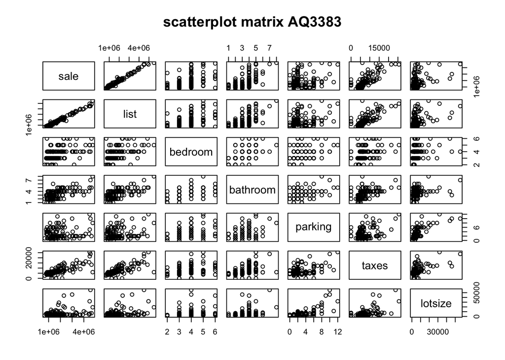

```r
pairs(sale~list+bedroom+bathroom+parking+taxes+lotsize, data = df_AQ3383, main="scatterplot matrix AQ3383")
```

```r
numericxy=cbind(df_AQ3383$sale,numericx)
round(cor(numericxy), 4)
```

```
##        [,1]   [,2]   [,3]   [,4]   [,5]   [,6]   [,7]
## [1,] 1.0000 0.9885 0.4607 0.6015 0.1623 0.7713 0.3784
## [2,] 0.9885 1.0000 0.4657 0.6147 0.2008 0.7556 0.3925
## [3,] 0.4607 0.4657 1.0000 0.5520 0.3336 0.3751 0.2761
## [4,] 0.6015 0.6147 0.5520 1.0000 0.3487 0.4653 0.3354
## [5,] 0.1623 0.2008 0.3336 0.3487 1.0000 0.3690 0.7211
## [6,] 0.7713 0.7556 0.3751 0.4653 0.3690 1.0000 0.5816
## [7,] 0.3784 0.3925 0.2761 0.3354 0.7211 0.5816 1.0000
```

b). pairwise correlations and scatterplot matrix for all pairs of quantitative variables in the data are shown above. The rank of each quantitative predictor for sale price in terms their correlation coefficient, from highest to lowest is list(0.9885) > taxes(0.7713) > bathroom(0.6015) > bedroom(0.4607) > lotsize(0.3784) > parking(0.1623)

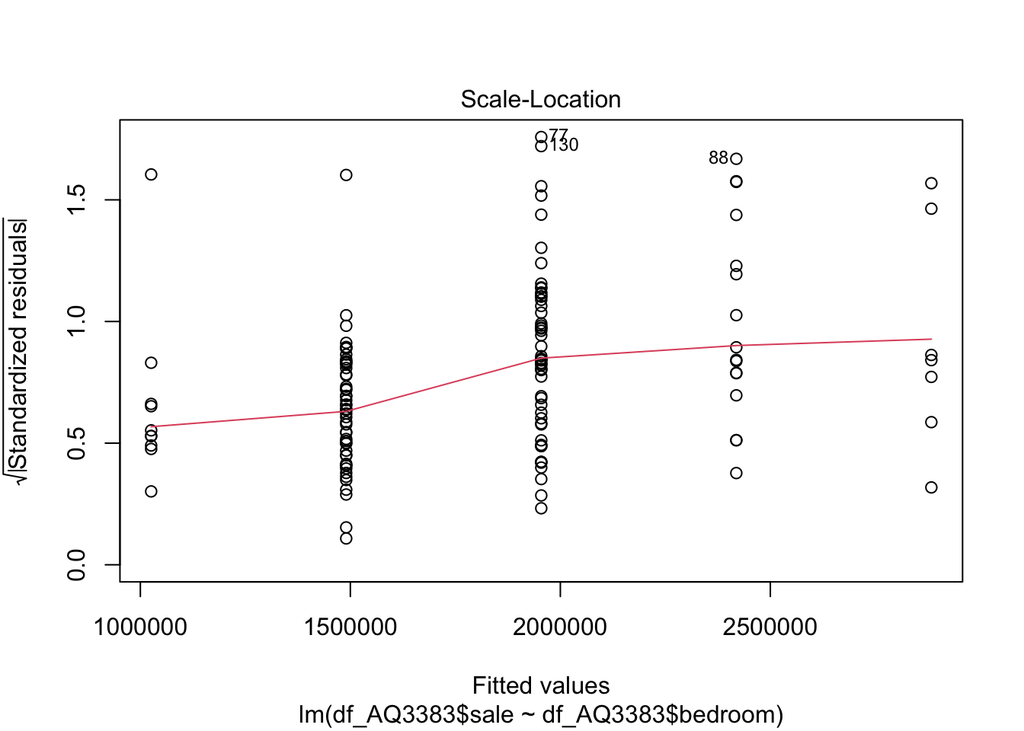

```r
model_violated = lm(df_AQ3383$sale~df_AQ3383$bedroom)
plot(model_violated, which=3)
```

c). Based on scatterplot matrix, bedroom of sale price would strongly violate the assumption of constant variance. The graph shown above is a SLR of sale price and number of bedrooms.

## III. Methods and Model

```r
model_AQ3383 = lm(df_AQ3383$sale~df_AQ3383$list+df_AQ3383$bedroom+df_AQ3383$bathroom+df_AQ3383$parking+df_AQ3383$taxes+df_AQ3383$location+df_AQ3383$lotsize)
summary(model_AQ3383)
```

```
##
## Call:
## lm(formula = df_AQ3383$sale ~ df_AQ3383$list + df_AQ3383$bedroom +
##     df_AQ3383$bathroom + df_AQ3383$parking + df_AQ3383$taxes +
##     df_AQ3383$location + df_AQ3383$lotsize)
##
## Residuals:
##     Min      1Q  Median      3Q     Max
## -386937  -81066  -10215   65030  586379
##
## Coefficients:
##                       Estimate Std. Error t value Pr(>|t|)
## (Intercept)          4.519e+04  5.735e+04   0.788   0.4322
## df_AQ3383$list       8.377e-01  2.185e-02  38.334  < 2e-16 ***
## df_AQ3383$bedroom    1.021e+04  1.489e+04   0.686   0.4940
## df_AQ3383$bathroom   1.394e+04  1.321e+04   1.055   0.2933
## df_AQ3383$parking   -1.616e+04  8.832e+03  -1.830   0.0695 .
## df_AQ3383$taxes      2.040e+01  4.591e+00   4.443 1.86e-05 ***
## df_AQ3383$locationT  8.126e+04  3.889e+04   2.090   0.0386 *
## df_AQ3383$lotsize    1.424e+00  2.282e+00   0.624   0.5337
## ---
## Signif. codes:  0 '***' 0.001 '**' 0.01 '*' 0.05 '.' 0.1 ' ' 1
##
## Residual standard error: 130200 on 132 degrees of freedom
## Multiple R-squared:  0.9821, Adjusted R-squared:  0.9812
## F-statistic:  1037 on 7 and 132 DF,  p-value: < 2.2e-16
```

1. above is additive linear regression model with all available predictors variables for sale price. According to graph shown above, list price and taxes has significant t-test results. This shows: Holding all other explanatory variables in the model fixed, for every $1 increase in the list price, on average sale price increases by 84 cents. Holding all other explanatory variables in the model fixed, for every $1 increase in taxes, on average sale price increases by $20.4.

```r
AIC_model_AQ3383 = step(model_AQ3383, direction = "backward")
```

```
## Start:  AIC=3305.33
## df_AQ3383$sale ~ df_AQ3383$list + df_AQ3383$bedroom + df_AQ3383$bathroom +
##     df_AQ3383$parking + df_AQ3383$taxes + df_AQ3383$location +
##     df_AQ3383$lotsize
##
##                      Df  Sum of Sq        RSS    AIC
## - df_AQ3383$lotsize   1 6.6052e+09 2.2452e+12 3303.7
## - df_AQ3383$bedroom   1 7.9768e+09 2.2466e+12 3303.8
## - df_AQ3383$bathroom  1 1.8882e+10 2.2575e+12 3304.5
## <none>                             2.2386e+12 3305.3
## - df_AQ3383$parking   1 5.6791e+10 2.2954e+12 3306.8
## - df_AQ3383$location  1 7.4055e+10 2.3127e+12 3307.9
## - df_AQ3383$taxes     1 3.3477e+11 2.5734e+12 3322.8
## - df_AQ3383$list      1 2.4922e+13 2.7161e+13 3652.8
##
## Step:  AIC=3303.75
## df_AQ3383$sale ~ df_AQ3383$list + df_AQ3383$bedroom + df_AQ3383$bathroom +
##     df_AQ3383$parking + df_AQ3383$taxes + df_AQ3383$location
##
##                      Df  Sum of Sq        RSS    AIC
## - df_AQ3383$bedroom   1 6.9400e+09 2.2522e+12 3302.2
## - df_AQ3383$bathroom  1 1.7542e+10 2.2628e+12 3302.8
## <none>                             2.2452e+12 3303.7
## - df_AQ3383$parking   1 5.2185e+10 2.2974e+12 3305.0
## - df_AQ3383$location  1 7.2162e+10 2.3174e+12 3306.2
## - df_AQ3383$taxes     1 4.1135e+11 2.6566e+12 3325.3
## - df_AQ3383$list      1 2.5095e+13 2.7341e+13 3651.7
##
## Step:  AIC=3302.18
## df_AQ3383$sale ~ df_AQ3383$list + df_AQ3383$bathroom + df_AQ3383$parking +
##     df_AQ3383$taxes + df_AQ3383$location
##
##                      Df  Sum of Sq        RSS    AIC
## - df_AQ3383$bathroom  1 3.0249e+10 2.2824e+12 3302.0
## <none>                             2.2522e+12 3302.2
## - df_AQ3383$parking   1 4.5876e+10 2.2981e+12 3303.0
## - df_AQ3383$location  1 8.3458e+10 2.3356e+12 3305.3
## - df_AQ3383$taxes     1 4.1236e+11 2.6645e+12 3323.7
## - df_AQ3383$list      1 2.5227e+13 2.7479e+13 3650.4
##
## Step:  AIC=3302.05
## df_AQ3383$sale ~ df_AQ3383$list + df_AQ3383$parking + df_AQ3383$taxes +
##     df_AQ3383$location
##
##                      Df  Sum of Sq        RSS    AIC
## <none>                             2.2824e+12 3302.0
## - df_AQ3383$parking   1 4.4557e+10 2.3270e+12 3302.8
## - df_AQ3383$location  1 6.2997e+10 2.3454e+12 3303.9
## - df_AQ3383$taxes     1 3.8801e+11 2.6704e+12 3322.0
## - df_AQ3383$list      1 3.7569e+13 3.9852e+13 3700.4
```

```r
AIC_model_AQ3383
```

```
##
## Call:
## lm(formula = df_AQ3383$sale ~ df_AQ3383$list + df_AQ3383$parking +
##     df_AQ3383$taxes + df_AQ3383$location)
##
## Coefficients:
##         (Intercept)       df_AQ3383$list    df_AQ3383$parking
##           9.905e+04            8.554e-01           -1.195e+04
##     df_AQ3383$taxes  df_AQ3383$locationT
##           2.048e+01            7.081e+04
```

```r
BIC_model_AQ3383 = step(model_AQ3383, direction = "backward", k=log(150))
```

```
## Start:  AIC=3329.42
## df_AQ3383$sale ~ df_AQ3383$list + df_AQ3383$bedroom + df_AQ3383$bathroom +
##     df_AQ3383$parking + df_AQ3383$taxes + df_AQ3383$location +
##     df_AQ3383$lotsize
##
##                      Df  Sum of Sq        RSS    AIC
## - df_AQ3383$lotsize   1 6.6052e+09 2.2452e+12 3324.8
## - df_AQ3383$bedroom   1 7.9768e+09 2.2466e+12 3324.9
## - df_AQ3383$bathroom  1 1.8882e+10 2.2575e+12 3325.6
## - df_AQ3383$parking   1 5.6791e+10 2.2954e+12 3327.9
## - df_AQ3383$location  1 7.4055e+10 2.3127e+12 3329.0
## <none>                             2.2386e+12 3329.4
## - df_AQ3383$taxes     1 3.3477e+11 2.5734e+12 3343.9
## - df_AQ3383$list      1 2.4922e+13 2.7161e+13 3673.8
##
## Step:  AIC=3324.82
## df_AQ3383$sale ~ df_AQ3383$list + df_AQ3383$bedroom + df_AQ3383$bathroom +
##     df_AQ3383$parking + df_AQ3383$taxes + df_AQ3383$location
##
##                      Df  Sum of Sq        RSS    AIC
## - df_AQ3383$bedroom   1 6.9400e+09 2.2522e+12 3320.2
## - df_AQ3383$bathroom  1 1.7542e+10 2.2628e+12 3320.9
## - df_AQ3383$parking   1 5.2185e+10 2.2974e+12 3323.0
## - df_AQ3383$location  1 7.2162e+10 2.3174e+12 3324.2
## <none>                             2.2452e+12 3324.8
## - df_AQ3383$taxes     1 4.1135e+11 2.6566e+12 3343.4
## - df_AQ3383$list      1 2.5095e+13 2.7341e+13 3669.7
##
## Step:  AIC=3320.24
## df_AQ3383$sale ~ df_AQ3383$list + df_AQ3383$bathroom + df_AQ3383$parking +
##     df_AQ3383$taxes + df_AQ3383$location
##
##                      Df  Sum of Sq        RSS    AIC
## - df_AQ3383$bathroom  1 3.0249e+10 2.2824e+12 3317.1
## - df_AQ3383$parking   1 4.5876e+10 2.2981e+12 3318.1
## <none>                             2.2522e+12 3320.2
## - df_AQ3383$location  1 8.3458e+10 2.3356e+12 3320.3
## - df_AQ3383$taxes     1 4.1236e+11 2.6645e+12 3338.8
## - df_AQ3383$list      1 2.5227e+13 2.7479e+13 3665.4
##
## Step:  AIC=3317.1
## df_AQ3383$sale ~ df_AQ3383$list + df_AQ3383$parking + df_AQ3383$taxes +
##     df_AQ3383$location
##
##                      Df  Sum of Sq        RSS    AIC
## - df_AQ3383$parking   1 4.4557e+10 2.3270e+12 3314.8
## - df_AQ3383$location  1 6.2997e+10 2.3454e+12 3315.9
## <none>                             2.2824e+12 3317.1
## - df_AQ3383$taxes     1 3.8801e+11 2.6704e+12 3334.1
## - df_AQ3383$list      1 3.7569e+13 3.9852e+13 3712.5
##
## Step:  AIC=3314.8
## df_AQ3383$sale ~ df_AQ3383$list + df_AQ3383$taxes + df_AQ3383$location
##
##                      Df  Sum of Sq        RSS    AIC
## <none>                             2.3270e+12 3314.8
## - df_AQ3383$taxes     1 3.6357e+11 2.6906e+12 3330.1
## - df_AQ3383$location  1 3.6570e+11 2.6927e+12 3330.2
## - df_AQ3383$list      1 3.8856e+13 4.1183e+13 3712.1
```

```r
BIC_model_AQ3383
```

```
##
## Call:
## lm(formula = df_AQ3383$sale ~ df_AQ3383$list + df_AQ3383$taxes +
##     df_AQ3383$location)
##
## Coefficients:
##         (Intercept)       df_AQ3383$list      df_AQ3383$taxes
##           5.045e+04            8.490e-01            1.970e+01
## df_AQ3383$locationT
##           1.148e+05
```

## IV. Discussions and Limitations

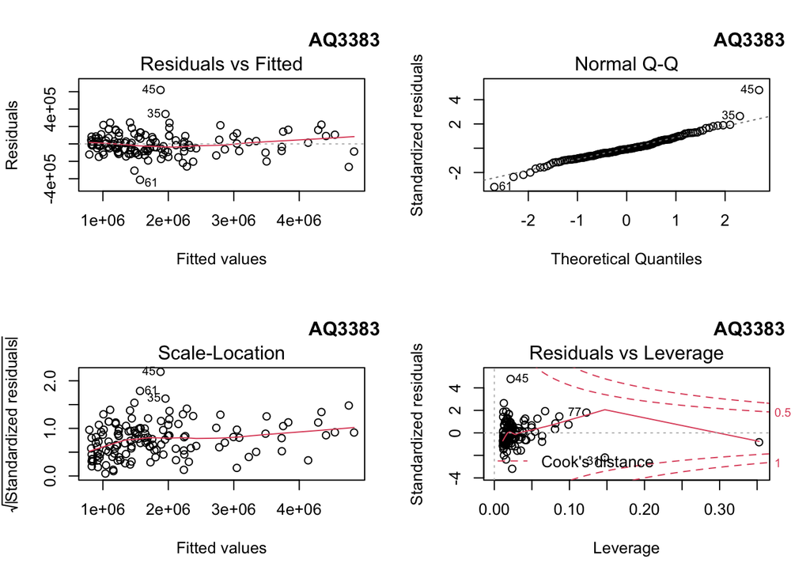

```r
par(mfrow=c(2,2))
plot(BIC_model_AQ3383, main = "                                              AQ3383")
```

1. Four diagnostic plots that are obtained in R by plotting the model obtained in part III iii) is shown above.

```
##     77     45     31     35     61     88      5     18    130     41      1
## 0.2957 0.0993 0.0918 0.0619 0.0497 0.0493 0.0428 0.0405 0.0298 0.0233 0.0221
##     95
## 0.0213
```

2. Residuals vs Fitted: the residuals are equally distributed above and under the horizontal line. This indicated we have a linear relationship. Case 45 and 61 seems a little bit off, but we don’t know what it is yet, so we’ll keep that in mind. Normal Q-Q: We can tell the residuals almost follow a straight line and barely deviate, but case 45 and 61 still concerns us. Note that we don’t have a heavy tale here, which is good. Scale-Location: a horizontal line shows majority of the residuals is spread equally along the range of predictors. This also shows we have homoscedasticity. As shown above in the previous graphs, case 45 is more irregular than case 61 here. Residuals vs Leverage: This is where we defines influential points, which are cases outside the dashed line called “cook’s distance”. According to code shown above, cases with cooks distance does not have a significant effect in the model. Therefore, we can concluded that neither case 45 nor case 61 are influential points, and according to four graphs above, we can safely say the model satisfies normality assumptions, constant variance and linearity.

c). In order to find a valid final model, I would probably fix the problem for “maxsqfoot”, which is the predictor we eliminated from the beginning since most of cases is missing its value. I would also add a few more predictors, for example, history rent prices. This makes sense because when purchasing a property as an investment, it’s sale price is always dependents on how much it can rent. If possible, using anova to calculate the F-tests is also a valid way to highlight the predictors of the model.